# ETL Exercises Notebook

Máster Universitario en Ciencia de Datos

CUNEF Universidad

All these exercises were prepared by *Leonado Hansa*, teacher in the Master’s Degree Data Science in CUNEF University.

# UNIT 3. General Tools

### **Exercise 1**

Using `ls` and `cd` in your computer explore your folders and the contents of the folder you use for the Master’s degree.

###### *Remark: If you use Windows, it is recommendable downloading Git Bash for Windows.*

**Solución**

`ls` es un comando bash para mostrar lo que hay en un directorio, mientras que `cd` es otro comando que, unido al nombre del directorio que quieras (p. ej. `ls Desktop`), se accede a la carpeta que se desee.

Primero empezaríamos con `ls` para mirar todas las carpetas que tenemos, y luego entraríamos a la carpeta con `cd ...`, y así.

### **Exercise 2**

Create in your local Desktop a file called `testing-bash.ter` and write in the text “Holi!”. Use `echo` and `>` for this. Then create a folder in your Documents folder named `carpeta_prueba`. Move the previous file inside this folder and, check with ls you’ve done it properly. Now use `cat` for checking the text actually written in the file. Finally, remove the folder `carpeta_prueba` with `rm`.

**Solución**

Poniendo `echo` en el Git Bash la consola me devuelve el texto que le puse:

```
rstudio@c0addac18593:~$ echo Hola
Hola
```

El signo `>` es un pipeline que se pasa al resultado del comando a otra función o archivo:

```
rstudio@c0addac18593:~$ echo Holi! > testing-bash.ter
rstudio@c0addac18593:~$ ls
etl  testing-bash.ter
```

Poniendo el comando ls vemos que hemos creado un archivo con el texto `Hola`. Ahora hemos creado un directorio y hemos movido el archivo dentro usando `mkdir` y `mv`, como se verá a continuación:

```
rstudio@c0addac18593:~$ mkdir carpeta_prueba
rstudio@c0addac18593:~$ ls
carpeta_prueba ...(demás carpetas del Desktop)...  testing-bash.ter
rstudio@c0addac18593:~$ mv testing-bash.ter carpeta_prueba
rstudio@c0addac18593:~$ ls
carpeta_prueba  etl
rstudio@c0addac18593:~$ cd carpeta_prueba
rstudio@c0addac18593:~/carpeta_prueba$ ls
testing-bash.ter
```

Además, podemos revisar qué hay dentro con la función `cat`, esto nos imprimirá en el resultado de la consola:

```
rstudio@c0addac18593:~/carpeta_prueba$ cat testing-bash.ter
Hola
```

Por último, vamos a borrar la carpeta. Se podría usar `rm` pero es que solo funciona para archivos, no para carpetas, por lo que usaremos el comando `rmdir` (de remove directory).

Otro problema que podemos ver es que la carpeta no está vacía. O bien vamos dentro de la carpeta, borramos el archivo y luego borramos la carpeta (a veces no renta), o bien usamos la propiedad `-rf` en la función, esto hará una recursive delete, borrando primero los archivos de dentro y luego la carpeta.

```
rstudio@c0addac18593:~/carpeta_prueba$ cd ..
rstudio@c0addac18593:~$ rm carpeta_prueba
rm: cannot remove 'carpeta_prueba': Is a directory
rstudio@c0addac18593:~$ rmdir carpeta_prueba
rmdir: failed to remove 'carpeta_prueba': Directory not empty
rstudio@c0addac18593:~$ rm -rf carpeta_prueba
rstudio@c0addac18593:~$ ls
etl
```

Dato curioso: te lo lleva en realidad a la papelera, no te lo deletea definitivamente.

### **Exercise 3**

Run a docker container from the image `lhansa/cunefark:0.1.0`, as shown in the Canvas notes. Explore the container with `ls` and `cd`. Create a Git repository in GitHub and link a folder inside this container to that repo.

**Solución**

*Docker*

Para crear el contenedor del ejercicio hay que abrir la terminal y escribir:

```
docker run -it -p 8888:8888 lhansa/cunefark:0.1.0 bash
```

Una vez que la imagen se ha descargado, el contenedor empezará a correr, podemos ahora usar entonces el `ps`:

```
PS C:\Users\alexg> ps
CONTAINER ID   IMAGE                   COMMAND   CREATED       STATUS         PORTS                                                                                  NAMES
c0addac18593   lhansa/cunefetl:0.1.1   "bash"   2 months ago   Up 7 minutes   0.0.0.0:8787->8787/tcp, :::8787->8787/tcp, 0.0.0.0:8888->8888/tcp, :::8888->8888/tcp   amazing_taussig
```

We can access our container using `docker exec` command:

```
PS C:\Users\alexg> docker exec -it amazing_taussig bash
rstudio@c0addac18593:/$
```

# ———————————————————–

# ———————————————————–

# UNIT 4: Extract

## Plain Text

### **Exercise 1**

With pandas, from *hipotecas_lectura* file read only the data from the second semester of 2020, and including somehow the names of the columns.

**Solución**

```
# import pandas as pd
# Mantendremos primero los nombres de las columnas con list():

# hipotecas = pd.read_csv('/home/rstudio/etl/data/hipotecas/hipotecas_lectura',
# nrows=3)
# cols = list(hipotecas.columns)

# Suprimiremos las primeras 7 filas y leeremos solo las 6 siguientes (correspondientes a los 6 últimos meses del 2020:

# hipotecas = pd.read_csv('/home/rstudio/etl/data/hipotecas/hipotecas_lectura',
#skiprows=7, nrows=6, names=cols)

# hipotecas.head(6)
```

**Otra alternativa**

```
# hipotecas = pd.read_csv('/home/rstudio/etl/data/hipotecas/hipotecas_lectura',
# skiprows= range(1, 7), nrows=6, header=0)
# hipotecas
```

### **Exercise 2**

With readr, from the `hipotecas_lectura` file read only the data from the first semester of 2020, and including somehow the names of the columns.

**Solución 2**

```r
library(readr)

# Buscar los nombres de las columnas del DF:

names <- names(read_csv('~/../Desktop/CUNEF/Máster en Data Science/6. ETL/00 Exercises PDF/hipotecas_lectura.csv'))
# Lectura del DF

hipotecas2 <- read_csv('~/../Desktop/CUNEF/Máster en Data Science/6. ETL/00 Exercises PDF/hipotecas_lectura.csv',
                       skip = 13, n_max = 6, col_names = names)
hipotecas2
```

```
## # A tibble: 6 x 21
##   period total_nacional andalucia aragon asturias_princi~ balears_illes canarias
##   <chr>           <dbl>     <dbl>  <dbl>            <dbl>         <dbl>    <dbl>
## 1 2020M~          26890      4713    657              572           728      824
## 2 2020M~          25630      4818    702              346           758     1259
## 3 2020M~          24155      5571    551              453           628      669
## 4 2020M~          27300        NA    809               NA            NA      962
## 5 2020M~          36702      6864     NA              694          1022      998
## 6 2020M~          40217        NA    985             1112          1496       NA
## # ... with 14 more variables: cantabria <dbl>, castilla_la_mancha <dbl>,
## #   castilla_y_leon <dbl>, cataluna <dbl>, ceuta <dbl>,
## #   comunitat_valenciana <dbl>, extremadura <dbl>, galicia <dbl>,
## #   madrid_comunidad_de <dbl>, melilla <dbl>, murcia_region_de <dbl>,
## #   navarra_comunidad_foral_de <dbl>, pais_vasco <dbl>, rioja_la <dbl>
```

### **Exercise 3**

Try your best reading the original file downloaded from the INE’s site, `hipotecas_numero_ine.csv`. *Remark*: you may need to specify that the encoding is “ISO-8859-2”.

**Solución**

```r
hipotecas_ine <- read.csv2('~/../Desktop/CUNEF/Máster en Data Science/6. ETL/00 Exercises PDF/hipotecas_numero_ine.csv',
                    skip = 6, nrows = 18 , fileEncoding = 'ISO-8859-2')
head(hipotecas_ine)
```

```
##         X Total.Nacional X01.Andalucía X02.Aragón X03.Asturias..Principado.de
## 1 2021M06         37.961         7.853      1.230                         623
## 2 2021M05         35.225         6.746        912                         709
## 3 2021M04         31.909         6.327        748                         525
## 4 2021M03         36.886         6.941        775                         615
## 5 2021M02         31.647         6.227        943                         585
## 6 2021M01         27.518         5.591        792                         555
##   X04.Balears..Illes X05.Canarias X06.Cantabria X08.Castilla...La.Mancha
## 1                852        1.084           721                    1.608
## 2                768        1.120           581                    1.326
## 3                677          861           435                    1.135
## 4                775        1.091           569                    1.475
## 5                743          831           431                    1.310
## 6                643          878           390                    1.114
##   X07.Castilla.y.León X09.Cataluna X18.Ceuta X10.Comunitat.Valenciana
```

[output cut: 27 more lines]

```
# import pandas as pd
# hip_ine = pd.read_csv('/home/rstudio/etl/data/hipotecas/hipotecas_numero_ine.csv'# ,
#                      skiprows=6, nrows=18, encoding='ISO-8859-2', delimiter=';')
# hip_ine.head()
```

## Excel

### **Exercise 1**

Read with Python and `pandas` the second sheet of the `ejemplos_lecturas.xlsx` file.

**Solución**

```
# import pandas as pd
# primera_hoja = pd.read_excel('ejemplos_lectura.xlsx', sheet_name='Fechas')
# segunda_hoja = pd.read_excel('ejemplos_lectura.xlsx', sheet_name='Holi')
```

Recordar que hay que ir al Excel y dar a mostrar la hoja oculta.

**Otra alternativa (con R)**

```r
library(readxl)
path_to_file <- 'ejemplos_lectura.xlsx'
df_ejemplos <- read_xlsx(path_to_file)
df_ejemplos
```

```
## # A tibble: 11 x 5
##    chungo_01 chungo_02                      chungo_03        chungo_04 chungo_05
##        <dbl> <chr>                          <chr>            <chr>     <chr>
##  1     44070 Hoy es 27 de agosto de 2020    Thursday, Augus~ 44070.9   8/27/20
##  2     44071 Hoy es 28 de agosto de 2020    Friday, August ~ 44071.9   8/28/20
##  3     44072 Hoy es 29 de agosto de 2020    Saturday, Augus~ 44072.9   8/29/20
##  4     44073 Hoy es 30 de agosto de 2020    Sunday, August ~ 44073.9   8/30/20
##  5     44074 Hoy es 31 de agosto de 2020    Monday, August ~ 44074.9   8/31/20
##  6     44075 Hoy es 1 de septiembre de 2020 Tuesday, Septem~ 44075.9   43839
##  7     44076 Hoy es 2 de septiembre de 2020 Wednesday, Sept~ 44076.9   43870
##  8     44077 Hoy es 3 de septiembre de 2020 Thursday, Septe~ 44077.9   43899
##  9     44078 Hoy es 4 de septiembre de 2020 Friday, Septemb~ 44078.9   43930
## 10     44079 Hoy es 5 de septiembre de 2020 Saturday, Septe~ 44079.9   43960
## 11     44080 Hoy es 6 de septiembre de 2020 Sunday, Septemb~ 44080.9   43991
```

Esto no era lo que queríamos, para mirar el número de hojas usaremos esto:

```r
excel_sheets(path_to_file)
```

```
## [1] "Holi"   "Fechas"
```

Resulta que la carpeta “Holi” estaba oculta.

```r
df_fechas <- read_xlsx(path_to_file, sheet = "Fechas", skip = 2, col_types = c(rep("skip", 3), rep("guess", 5)))
df_fechas
```

```
## # A tibble: 11 x 5
##    fecha_01            fecha_02            fecha_03
##    <dttm>              <dttm>              <dttm>
##  1 2020-08-27 00:00:00 2020-08-27 00:00:00 2020-08-27 00:00:00
##  2 2020-08-28 00:00:00 2020-08-28 00:00:00 2020-08-28 00:00:00
##  3 2020-08-29 00:00:00 2020-08-29 00:00:00 2020-08-29 00:00:00
##  4 2020-08-30 00:00:00 2020-08-30 00:00:00 2020-08-30 00:00:00
##  5 2020-08-31 00:00:00 2020-08-31 00:00:00 2020-08-31 00:00:00
##  6 2020-09-01 00:00:00 2020-09-01 00:00:00 2020-09-01 00:00:00
##  7 2020-09-02 00:00:00 2020-09-02 00:00:00 2020-09-02 00:00:00
##  8 2020-09-03 00:00:00 2020-09-03 00:00:00 2020-09-03 00:00:00
##  9 2020-09-04 00:00:00 2020-09-04 00:00:00 2020-09-04 00:00:00
## 10 2020-09-05 00:00:00 2020-09-05 00:00:00 2020-09-05 00:00:00
## 11 2020-09-06 00:00:00 2020-09-06 00:00:00 2020-09-06 00:00:00
## # ... with 2 more variables: fecha_04 <dttm>, fecha_05 <dttm>
```

## SQL

### **Exercise 1**

In R, download all the rows from `IndexPrice` in **indexKaggle.SQlite** whose region is United States or Europe, from 2019 until the end of the period.

**Solución**

```r
library(dplyr)
conn <- DBI::dbConnect(RSQLite::SQLite(), 'indexKaggle.sqlite') # Conexión con la BBDD
DBI::dbListTables(conn) # Listando las tablas
```

```
## [1] "IndexMeta"  "IndexPrice"
```

```r
DBI::dbListFields(conn, 'IndexPrice') # Lectura del IndexPrice e IndexMeta
```

```
## [1] "stock_index" "date"        "open"        "high"        "low"
## [6] "close"       "adj_close"   "volume"
```

```r
DBI::dbListFields(conn, 'IndexMeta')
```

```
## [1] "region"      "exchange"    "stock_index" "currency"
```

```r
# Todo lo anterior se tiene ejecutar junto, por separado da error.

# Necesitamos unir ambas tablas, así que necesitamos hacer una query para saber la región del índice del stock y así extraer los valores correspondientes al año 2009

query = "
SELECT p.stock_index, date, open, high,
low, close, adj_close, volume
FROM IndexPrice p INNER JOIN IndexMeta m ON(p.stock_index == m.stock_index)
WHERE (m.region == 'United States' OR m.region == 'Europe') AND
strftime('%Y', p.date) == '2009'
"
table <- tbl(conn, sql(query))
table %>% collect() # con esto ejecutamos la query
```

```
## # A tibble: 760 x 8
##    stock_index date       open        high        low    close  adj_close volume
##    <chr>       <chr>      <chr>       <chr>       <chr>  <chr>  <chr>     <chr>
##  1 NYA         2009-01-02 5755.759766 5937.02002  5732.~ 5915.~ 5915.729~ 40482~
##  2 NYA         2009-01-05 5915.720215 5963.700195 5839.~ 5908.~ 5908.430~ 54139~
##  3 NYA         2009-01-06 5908.390137 6014        5901.~ 5968.~ 5968.839~ 53926~
##  4 NYA         2009-01-07 5968.839844 5968.839844 5770.~ 5799.~ 5799.049~ 47049~
##  5 NYA         2009-01-08 5799.049805 5839.490234 5741.~ 5837.~ 5837.140~ 49915~
##  6 NYA         2009-01-09 5838.569824 5842.060059 5691.~ 5702.~ 5702.370~ 47165~
##  7 NYA         2009-01-12 5702.379883 5702.379883 5515.~ 5551.~ 5551.029~ 47250~
##  8 NYA         2009-01-13 5551.029785 5560.450195 5476.~ 5538.~ 5538.839~ 55674~
##  9 NYA         2009-01-14 5538.689941 5538.689941 5284.~ 5328.~ 5328.680~ 54078~
## 10 NYA         2009-01-15 5328.680176 5394.339844 5161.~ 5347.~ 5347.75   78073~
## # ... with 750 more rows
```

```r
# Para cerrar conexión con la BBDD

DBI::dbDisconnect(conn)
```

**Exercise 2**

In R and Python, from **indexKaggle.SQlite** download a table containing all the close prices and volume since 2007 until 2010 whose currency is dollars or euros.

**Solución**

Con **R**:

```r
library(dplyr)
conn <- DBI::dbConnect(RSQLite::SQLite(), 'indexKaggle.sqlite')
DBI::dbListTables(conn)
```

```
## [1] "IndexMeta"  "IndexPrice"
```

```r
DBI::dbListFields(conn, 'IndexPrice')
```

```
## [1] "stock_index" "date"        "open"        "high"        "low"
## [6] "close"       "adj_close"   "volume"
```

```r
DBI::dbListFields(conn, 'IndexMeta')
```

```
## [1] "region"      "exchange"    "stock_index" "currency"
```

```r
# Necesitamos unir ambas tablas y necesitamos una query que nos haga saber el índice actual del stock:

query <- "
SELECT p.stock_index, adj_close, volume
FROM IndexPrice p INNER JOIN IndexMeta m ON(p.stock_index == m.stock_index)
WHERE (m.currency == 'EUR' OR m.currency == 'USD') AND
strftime('%Y', p.date) BETWEEN '2007' AND '2009'
"
table <- tbl(conn, sql(query))
table %>% collect()
```

```
## # A tibble: 3,039 x 3
##    stock_index adj_close   volume
##    <chr>       <chr>       <chr>
##  1 NYA         9133.080078 3429160000
##  2 NYA         9113.160156 0
##  3 NYA         9025.040039 2919400000
##  4 NYA         9041.120117 2763340000
##  5 NYA         9023.900391 3038380000
##  6 NYA         9003.120117 2764660000
##  7 NYA         9063.089844 2857870000
##  8 NYA         9139.94043  2686480000
##  9 NYA         9139.55957  2599530000
## 10 NYA         9146.259766 2690270000
## # ... with 3,029 more rows
```

```r
DBI::dbDisconnect(conn)
```

Con **Python**:

```
# import pandas as pd
# from sqlalchemy import create_engine
# engine = create_engine('indexKaggle.sqlite')
# query = '''
# SELECT p.stock_index, adj_close, volume
# FROM IndexPrice p INNER JOIN IndexMeta m ON(p.stock_index == m.stock_index)
# WHERE (m.currency == 'EUR' OR m.currency == 'USD') AND
# strftime('%Y', p.date) BETWEEN '2007' AND '2009'
# '''
# table = pd.read_sql(query, engine)
# table.head()
```

### **Exercise 3**

With R or Python, use the `elections2016.sqlite` database for extracting some data. We want a table that includes all the adjusted polls for Trump and Clinton in the Ohio and Pennsylvania states, along with the final results, order from the newest poll to the oldest (considering only the `enddate` column). The final table will have the next columns: * (From the `Polls` table) state, enddate, grade, samplesize, adjpoll_clinton, adjpoll_trump. * (From the `Results` table) electoral_votes, clinton, trump.

**Solución**

Con **R**:

```r
conn <- DBI::dbConnect(RSQLite::SQLite(), 'elections2016.sqlite')
DBI::dbListFields(conn, 'Polls')
```

```
##  [1] "state"            "startdate"        "enddate"          "pollster"
##  [5] "grade"            "samplesize"       "population"       "rawpoll_clinton"
##  [9] "rawpoll_trump"    "rawpoll_johnson"  "rawpoll_mcmullin" "adjpoll_clinton"
## [13] "adjpoll_trump"    "adjpoll_johnson"  "adjpoll_mcmullin"
```

```r
DBI::dbListFields(conn, 'Results')
```

```
## [1] "state"           "electoral_votes" "clinton"         "trump"
## [5] "others"
```

```r
query <- "
SELECT p.state, p.enddate, p.grade, p.samplesize, p.adjpoll_clinton,
p.adjpoll_trump, r.electoral_votes, r.clinton, r.trump
FROM Polls p INNER JOIN Results r ON(p.state == r.state)
WHERE p.state == 'Ohio' OR p.state == 'Pennsylvania'
ORDER BY p.enddate DESC
"
table <- tbl(conn, sql(query))
table %>% collect()
```

```
## # A tibble: 240 x 9
##    state  enddate grade samplesize adjpoll_clinton adjpoll_trump electoral_votes
##    <chr>  <chr>   <chr>      <int>           <dbl>         <dbl>           <int>
##  1 Ohio   2016-1~ C-          2860            40.6          44.3              18
##  2 Penns~ 2016-1~ C-          2845            44.6          42.3              20
##  3 Penns~ 2016-1~ B           1177            43.0          42.8              20
##  4 Ohio   2016-1~ B           1070            40.3          43.7              18
##  5 Ohio   2016-1~ B-          1781            41.8          47.3              18
##  6 Penns~ 2016-1~ B-          1220            45.8          39.3              20
##  7 Penns~ 2016-1~ C+           525            44.6          46.1              20
##  8 Ohio   2016-1~ C+           525            44.6          43.1              18
##  9 Ohio   2016-1~ A-           552            46.2          44.9              18
## 10 Penns~ 2016-1~ A-           498            47.6          44.4              20
## # ... with 230 more rows, and 2 more variables: clinton <dbl>, trump <dbl>
```

Con **Python**:

```
# import pandas as pd
# from sqlalchemy import create_engine
# engine = create_engine('elections2016.sqlite')
# query = '''
# SELECT p.state, p.enddate, p.grade, p.samplesize, p.adjpoll_clinton,
# p.adjpoll_trump, r.electoral_votes, r.clinton, r.trump
# FROM Polls p INNER JOIN Results r ON(p.state == r.state)
# WHERE p.state == 'Ohio' OR p.state == 'Pennsylvania'
# ORDER BY p.enddate DESC
# '''
# table = pd.read_sql(query, engine)
# table.head()
```

### **Exercise 4**

In the **Pets** database, check if there is any owner with more the one pet.

**Solución**

Con **R**:

```r
conn <- DBI::dbConnect(RSQLite::SQLite(), 'pets.sqlite')
DBI::dbListTables(conn)
```

```
## [1] "OLTP"              "Owners"            "Pets"
## [4] "ProceduresDetails" "ProceduresHistory"
```

```r
DBI::dbListFields(conn, 'Owners')
```

```
## [1] "OwnerID"       "Name"          "Surname"       "StreetAddress"
## [5] "City"          "State"         "StateFull"     "ZipCode"
```

```r
DBI::dbListFields(conn, 'Pets')
```

```
## [1] "PetID"   "Name"    "Kind"    "Gender"  "Age"     "OwnerID"
```

```r
query <- "
SELECT o.OwnerID, count(p.PetID)
FROM Owners o INNER JOIN Pets p ON(o.OwnerID == p.OwnerID)
GROUP BY o.OwnerID
HAVING count(p.PetID) > 1
"
table <- tbl(conn, sql(query))
table %>% collect()
```

```
## # A tibble: 8 x 2
##   OwnerID `count(p.PetID)`
##     <int>            <int>
## 1    1306                2
## 2    3089                3
## 3    5508                3
## 4    6102                2
## 5    7484                2
## 6    7846                2
## 7    8133                3
## 8    9850                2
```

Con **Python**:

```
# import pandas as pd
# from sqlalchemy import create_engine
# engine = create_engine('pets.sqlite')
# query = '''
# SELECT o.OwnerID, count(p.PetID)
# FROM Owners o INNER JOIN Pets p ON(o.OwnerID == p.OwnerID)
# GROUP BY o.OwnerID
# HAVING count(p.PetID) > 1
# '''
# table = pd.read_sql(query, engine)
# table.head()
```

### **Exercise 5**

Calculate the income per day considering all procedures.

**Solución**

En **R**:

```r
conn <- DBI::dbConnect(RSQLite::SQLite(), 'pets.sqlite')
DBI::dbListTables(conn)
```

```
## [1] "OLTP"              "Owners"            "Pets"
## [4] "ProceduresDetails" "ProceduresHistory"
```

```r
DBI::dbListFields(conn, 'ProceduresDetails')
```

```
## [1] "ProcedureType"    "ProcedureSubCode" "Description"      "Price"
```

```r
DBI::dbListFields(conn, 'ProceduresHistory')
```

```
## [1] "PetID"            "Date"             "ProcedureType"    "ProcedureSubCode"
```

```r
query <- "
SELECT h.date, AVG(d.price)
FROM ProceduresHistory h INNER JOIN ProceduresDetails d
    ON(h.ProcedureType == d.ProcedureType AND
        h.ProcedureSubCode == d.ProcedureSubCode)
GROUP BY h.date
"
table <- tbl(conn, sql(query))
table %>% collect()
```

```
## # A tibble: 356 x 2
##    Date       `AVG(d.price)`
##    <chr>               <dbl>
##  1 2016-01-10           10
##  2 2016-01-11           10
##  3 2016-01-12           91.4
##  4 2016-01-13           16.7
##  5 2016-01-14           15
##  6 2016-01-15          125
##  7 2016-01-16           31.0
##  8 2016-01-17           41.5
##  9 2016-01-18           50
## 10 2016-01-19          164.
## # ... with 346 more rows
```

Con **Python**:

```
# import pandas as pd
# from sqlalchemy import create_engine
# engine = create_engine('sqlite:///../data/pets.sqlite')
# query = '''
# SELECT h.date, AVG(d.price)
# FROM ProceduresHistory h INNER JOIN ProceduresDetails d
#     ON(h.ProcedureType == d.ProcedureType AND
#         h.ProcedureSubCode == d.ProcedureSubCode)
# GROUP BY h.date
# '''
# table = pd.read_sql(query, engine)
# table.head()
```

### **Exercise 6**

Using `strftime()`, calculate the income per month considering only the transactions done by owners from the largest city in the database (the largest city is the one with a larger number of owners)

**Solución**

Con **R**:

```r
conn <- DBI::dbConnect(RSQLite::SQLite(), 'pets.sqlite')
query2 <- "
SELECT strftime('%Y-%m',  h.Date), AVG(d.price)
FROM ProceduresHistory h INNER JOIN ProceduresDetails d
    ON(h.ProcedureType == d.ProcedureType AND
        h.ProcedureSubCode == d.ProcedureSubCode)
        INNER JOIN Pets p ON (h.PetID == p.PetID)
        INNER JOIN Owners o ON (p.OwnerID == o.OwnerID)
WHERE o.City IN
                (SELECT City
                  FROM Owners
                  GROUP BY City
                  ORDER BY COUNT(*) DESC
                  LIMIT 1)
GROUP BY strftime('%Y-%m',  h.Date)
"
table <- tbl(conn, sql(query2))
table %>% collect()
```

```
## # A tibble: 6 x 2
##   `strftime('%Y-%m',  h.Date)` `AVG(d.price)`
##   <chr>                                 <dbl>
## 1 2016-01                                  10
## 2 2016-05                                  10
## 3 2016-07                                  10
## 4 2016-08                                  15
## 5 2016-10                                  10
## 6 2016-12                                  10
```

Se usa la misma query para Python pero usando la sintaxis de `sqlalchemy`

## Spark

Antes de empezar este ejercicio, la siguiente preparación tiene que realizarse:

```
# Creating the spark session
# spark = SparkSession.builder.master("local[4]") \
#                     .appName('sparklyr') \
#                     .getOrCreate()
# flights = spark.read.csv('flights.csv', header=True)
# flights.createOrReplaceTempView("flights")
```

### **Exercise 1**

How many origin airports are there in the `flights` table?

**Solución**

```
# flights.select('origin').distinct().count()
```

### **Exercise 2**

How many destinations airport are for each origin airport?

**Solución**

```
# conteo_aux = flights.select('dest', 'origin').distinct()
# conteo_aux.groupBy('origin').count().show()
```

### **Exercise 3**

Calculate de average departure delay for each origin airport. **Solution 3**

```
# from pyspark.sql.types import DoubleType
# flights = flights.withColumn('dep_delay', flights['dep_delay'].cast(DoubleType()))
# flights.select('origin', 'dep_delay').groupBy('origin').avg('dep_delay').show()
```

### **Exercise 4**

Remove the registers whose travelling distance is greater than the 95% of the travelling distances.

**Solución**

```
# from pyspark.sql.types import DoubleType
# flights = flights.withColumn('distance', flights['distance'].cast(DoubleType()))
# Computamos el cuantil 95
# flights_ord = flights.select('distance').sort('distance') # order the distances
# element_95 = int(flights_ord.count() * 0.95) # position 0.95
# value_95 = flights_ord.collect()[element_95][0]
# Filtramos todos los valores con distancia mayor al cuantil 95
# flights_95 = flights.filter(flights['distance'] <= value_95)
# flights_95.show(6)
```

# ———————————————————–

# ———————————————————–

# UNIT 5: Transform

## Missing Values

### **Exercise 1**

Finish replacing the **NA** values from `df_simulated` data frame using the column known distributions. For column V5 use a normal distribution with a mean and a variance you consider appropriate.

**Solución**

En el R-Studio remoto, mirar el documento `code/05b-transform-missing.R`.

```
#V1
how_many_na <- sum(is.na(df_imputed$V1))
df_imputed$V1[is.na(df_imputed$V1)] <- runif(how_many_na)
#V2
how_many_na <- sum(is.na(df_imputed$V2))
df_imputed$V2[is.na(df_imputed$V2)] <- rnorm(how_many_na, mean = 0, sd = 1)
#V3
how_many_na <- sum(is.na(df_imputed$V3))
df_imputed$V3[is.na(df_imputed$V3)] <- rnorm(how_many_na, mean = 100, sd = sqrt(10))
#v4
how_many_na <- sum(is.na(df_imputed$V4))
df_imputed$V4[is.na(df_imputed$V4)] <- rpois(how_many_na, lambda = 10)
#V5
how_many_na <- sum(is.na(df_imputed$V5))
df_imputed$V5[is.na(df_imputed$V5)] <- seq(1, 15)
```

### **Exercise 2**

Given the next vector, replace every **NA** value with the previous non **NA** value.

**Solución**

```r
# El vector en cuestión:
set.seed(5678)
vector_letters <- sample(letters, 50, TRUE)
vector_letters[sample(seq_len(50), 25)] <- NA

# Miremos la composición de vector_letters
vector_letters
```

```
##  [1] NA  "l" NA  NA  "u" NA  "h" NA  "y" NA  NA  "d" NA  NA  "e" "y" NA  "m" NA
## [20] "w" "s" "m" "d" NA  NA  NA  "y" "w" NA  NA  "i" "c" "d" "f" NA  NA  "o" "h"
## [39] NA  NA  NA  "g" NA  "d" "x" NA  NA  "x" "i" NA
```

```r
# Como se puede ver, tenemos valores NA. Usaremos 'a' para sustituir el primer NA (ya que no hay ningún valor previo a dicho NA) y rellenemos el resto de NAs con el valor anterior:
previo <- "a"
posterior <- 1
for (value in vector_letters) {
  if (is.na(value)) {
    vector_letters[posterior] <- previo
  } else {
    previo <- value
  }
  posterior <- posterior + 1
}

vector_letters
```

```
##  [1] "a" "l" "l" "l" "u" "u" "h" "h" "y" "y" "y" "d" "d" "d" "e" "y" "y" "m" "m"
## [20] "w" "s" "m" "d" "d" "d" "d" "y" "w" "w" "w" "i" "c" "d" "f" "f" "f" "o" "h"
## [39] "h" "h" "h" "g" "g" "d" "x" "x" "x" "x" "i" "i"
```

### **Exercise 3**

Replace all the **NA** of the column V5 in `df_simulated` data frame using the moving average approach - with a period not longer than 1.

**Solución**

En el R-Studio remoto, mirar el documento `code/05c-transform-missing.R`.

```
library(purrr)
df_imputed <- df_simulated
df_imputed$V5 <- imap_dbl(df_simulated$V5, function(.x, .y){
  # .x represents the value in the iteration
  # .y represents the index of the interation

  if(!is.na(.x)){
   return(.x)
  } else {
  prev_value <- df_simulated$V5[.y - 1]
  next_value <- df_simulated$V5[.y + 1]

  return(mean(c(prev_value, next_value)))
  }
})
```

### **Exercise 4**

Build a function for scaling the `iris` dataset with the *min_max* approach and scale all the numeric columns.

**Solución**

```r
library(dplyr)

# Definimos el mínimo y máximo de la función aproximada
weight <- function(value, mini, maxi) {
  return((value-mini)/(maxi-mini))
}
# Se hace la conversión
iris_scaled <- iris %>%
  mutate(across(where(is.numeric), ~ weight(., min(.), max(.))))
iris_scaled %>%
  summarise(across(where(is.numeric), list(mean = mean, sd = sd)))
```

```
##   Sepal.Length_mean Sepal.Length_sd Sepal.Width_mean Sepal.Width_sd
## 1         0.4287037       0.2300184        0.4405556       0.181611
##   Petal.Length_mean Petal.Length_sd Petal.Width_mean Petal.Width_sd
## 1         0.4674576       0.2992031        0.4580556       0.317599
```

### **Exercise 5**

For the data frame `iris` build new functions `setosa`, `versicolor` and `virginica`. `setosa` will equal 1 if `Species == setosa` and 0 in the other case.

**Solución**

Este es un ejercicio sobre **codificar variables categóricas (apartado 4 del tema 5 TRANSFORMACIÓN)**

```r
library(dplyr)
iris_encoded <- iris %>%
  mutate(setosa = if_else(Species == 'setosa', 1, 0),
         versicolor = if_else(Species == 'versicolor', 1, 0),
         virginica = if_else(Species == 'virginica', 1, 0)) %>%
  select(Species, setosa, versicolor, virginica)
head(iris_encoded)
```

```
##   Species setosa versicolor virginica
## 1  setosa      1          0         0
## 2  setosa      1          0         0
## 3  setosa      1          0         0
## 4  setosa      1          0         0
## 5  setosa      1          0         0
## 6  setosa      1          0         0
```

## Dates and Time Series

### **Exercise 1**

Extract from the `Pets` database the daily number of procedures from the `ProceduresHistory` table.

**Solución**

```r
library(dplyr)
conn <- DBI::dbConnect(RSQLite::SQLite(), 'pets.sqlite')
query <- "
SELECT Date, COUNT(*)
FROM ProceduresHistory
GROUP BY Date
"
table <- tbl(conn, sql(query)) %>% collect()
head(table)
```

```
## # A tibble: 6 x 2
##   Date       `COUNT(*)`
##   <chr>           <int>
## 1 2016-01-10          1
## 2 2016-01-11          3
## 3 2016-01-12          7
## 4 2016-01-13         12
## 5 2016-01-14          1
## 6 2016-01-15          1
```

### **Exercise 2**

In that table you extracted in the previous exercise, create a new column that equals 1 if the date is a Sunday; 0, elsewhere. For knowing when a date is Sunday, you can use something like `format(a_date, format = "%u")`, which output the weekday number (7 for Sundays). **Remark**. The column must be of type `Date`.

**Solución**

```r
library(dplyr)
table_sunday <- table %>%
  mutate(Sunday = if_else(format(as.Date(Date), format = "%u") == "7", 1, 0))
table_sunday %>% filter(Sunday == 1) %>% head()
```

```
## # A tibble: 6 x 3
##   Date       `COUNT(*)` Sunday
##   <chr>           <int>  <dbl>
## 1 2016-01-10          1      1
## 2 2016-01-17          2      1
## 3 2016-01-24          3      1
## 4 2016-01-31         10      1
## 5 2016-02-07          2      1
## 6 2016-02-14         12      1
```

### **Exercise 3**

During February 4th 2016 there was a peak, a very extreme value. Create a column with a dummy variable indicating that date.

**Solución**

```r
library(dplyr)
table %>%
  mutate(Anomaly = if_else(Date == '2016-02-04', 1, 0)) %>%
  filter(format(as.Date(Date), format = '%m') == "02") %>%
  head()
```

```
## # A tibble: 6 x 3
##   Date       `COUNT(*)` Anomaly
##   <chr>           <int>   <dbl>
## 1 2016-02-01         25       0
## 2 2016-02-02         25       0
## 3 2016-02-03         45       0
## 4 2016-02-04         68       1
## 5 2016-02-05         27       0
## 6 2016-02-06          3       0
```

### **Exercise 5**

Let’s go now with something independent from the previous data. Imagine we have a data frame like the one created from the next code. The ﬁrst column indicates the beginning and end of each week of 2021, but in a terrible format. Create a new column with only the ﬁrst date of each week, but with the format `yyyy-mm-dd`.

**Solución**

```r
library(dplyr)
crear_dias <- function(ini, fin) {
  format(seq(as.Date(ini), as.Date(fin), by = 7),
  format = "%d/%m/%Y")
}

fechas_horribles <- paste(
  crear_dias("2020-12-28", "2021-12-27"),
  crear_dias("2021-01-03", "2022-01-02"),
  sep = " - "
)
df <- tibble(
  semana = fechas_horribles,
  metrica = runif(length(fechas_horribles))
)
df
```

```
## # A tibble: 53 x 2
##    semana                  metrica
##    <chr>                     <dbl>
##  1 28/12/2020 - 03/01/2021  0.317
##  2 04/01/2021 - 10/01/2021  0.464
##  3 11/01/2021 - 17/01/2021  0.324
##  4 18/01/2021 - 24/01/2021  0.877
##  5 25/01/2021 - 31/01/2021  0.136
##  6 01/02/2021 - 07/02/2021  0.859
##  7 08/02/2021 - 14/02/2021  0.248
##  8 15/02/2021 - 21/02/2021  0.868
##  9 22/02/2021 - 28/02/2021  0.0633
## 10 01/03/2021 - 07/03/2021  0.570
## # ... with 43 more rows
```

```r
# Solución

df %>%
  mutate(start = as.Date(semana, format = '%d/%m/%Y')) %>%
  head()
```

```
## # A tibble: 6 x 3
##   semana                  metrica start
##   <chr>                     <dbl> <date>
## 1 28/12/2020 - 03/01/2021   0.317 2020-12-28
## 2 04/01/2021 - 10/01/2021   0.464 2021-01-04
## 3 11/01/2021 - 17/01/2021   0.324 2021-01-11
## 4 18/01/2021 - 24/01/2021   0.877 2021-01-18
## 5 25/01/2021 - 31/01/2021   0.136 2021-01-25
## 6 01/02/2021 - 07/02/2021   0.859 2021-02-01
```

# ———————————————————–

# ———————————————————–

# UNIT 6: Load

### **Exercise 1**

Repeat with R all the process shown in Python for the `indexKaggle.sqlite` database

**Solución**

```r
library(dplyr)
library(purrr)
library(ggplot2)
conn <- DBI::dbConnect(RSQLite::SQLite(), 'indexKaggle.sqlite')
query = "
  SELECT IndexMeta.region, IndexPrice.stock_index,
         IndexPrice.date,
         IndexPrice.adj_close, IndexPrice.volume,
         IndexMeta.currency
  FROM IndexPrice INNER JOIN IndexMeta
      ON IndexPrice.stock_index = IndexMeta.stock_index
  WHERE IndexMeta.region in ('United States', 'Europe') and
      IndexPrice.date >= '2019-01-01' and
      IndexPrice.adj_close is not null
"
table <- tbl(conn, sql(query)) %>% collect()
head(table)
```

```
## # A tibble: 6 x 6
##   region        stock_index date       adj_close   volume     currency
##   <chr>         <chr>       <chr>      <chr>       <chr>      <chr>
## 1 United States NYA         2019-01-02 11383.53027 3733160000 USD
## 2 United States NYA         2019-01-03 11190.44043 3822860000 USD
## 3 United States NYA         2019-01-04 11533.33984 4213410000 USD
## 4 United States NYA         2019-01-07 11605.95996 4104710000 USD
## 5 United States NYA         2019-01-08 11716.23047 4081030000 USD
## 6 United States NYA         2019-01-09 11778.41992 4052480000 USD
```

```r
# Adj_close value to numeric
table <- table %>%
  mutate(adj_close = as.numeric(adj_close)) %>%
  mutate(date = as.Date(date))
table$adj_close <- imap_dbl(table$adj_close, function(.x, .y){
  # .x represents the value in the iteration
  # .y represents the index of the interation

  if(!is.na(.x)){
   return(.x)
  } else {
  prev_value <- table$adj_close[.y - 1]
  next_value <- table$adj_close[.y + 1]

  return(mean(c(prev_value, next_value)))
  }
})
# There isn't NA values
sum(is.na(table['adj_close']))
```

```
## [1] 0
```

```r
# Creating a table for each index
c(unique(table$stock_index))
```

```
## [1] "NYA"  "IXIC" "N100"
```

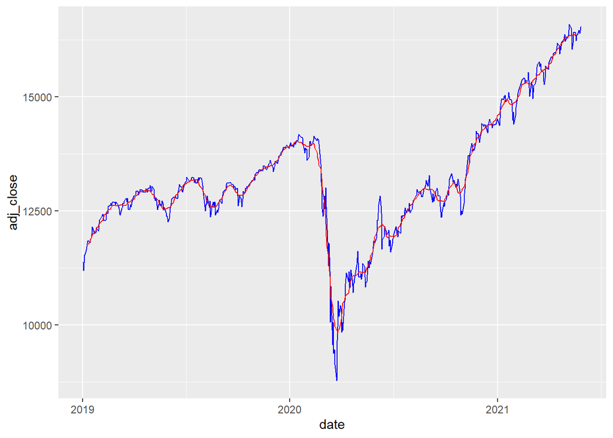

```r
  nya <- table %>%
    filter(stock_index == 'NYA') %>%
    select(date, adj_close) %>%
    mutate(smoothed = zoo::rollmean(adj_close, k = 15, fill=NA))

  ixic <- table %>%
    filter(stock_index == 'IXIC') %>%
    select(date, adj_close) %>%
    mutate(smoothed = zoo::rollmean(adj_close, k = 15, fill=NA))

  n100 <- table %>%
    filter(stock_index == 'N100') %>%
    select(date, adj_close) %>%
    mutate(smoothed = zoo::rollmean(adj_close, k = 15, fill=NA))

ggplot(nya, aes(x=date)) +
  geom_line(aes(y=adj_close), color = 'blue') +
  geom_line(aes(y=smoothed), color = 'red')
```

```r
# Insert tables
DBI::dbCreateTable(conn, 'NYA', nya)
DBI::dbCreateTable(conn, 'IXIC', ixic)
DBI::dbCreateTable(conn, 'N100', n100)
# Populate tables
DBI::dbAppendTable(conn, 'NYA', nya)
```

```
## [1] 607
```

```r
DBI::dbAppendTable(conn, 'IXIC', ixic)
```

```
## [1] 607
```

```r
DBI::dbAppendTable(conn, 'N100', n100)
```

```
## [1] 619
```

```r
# Check tables
DBI::dbListTables(conn)
```

```
## [1] "IXIC"       "IndexMeta"  "IndexPrice" "N100"       "NYA"
```

```r
tbl(conn, sql('SELECT * FROM NYA')) %>% collect()
```

```
## # A tibble: 607 x 3
##     date adj_close smoothed
##    <dbl>     <dbl>    <dbl>
##  1 17898    11384.      NA
##  2 17899    11190.      NA
##  3 17900    11533.      NA
##  4 17903    11606.      NA
##  5 17904    11716.      NA
##  6 17905    11778.      NA
##  7 17906    11839.      NA
##  8 17907    11848.   11776.
##  9 17910    11799.   11819.
## 10 17911    11869.   11881.
## # ... with 597 more rows
```

```r
# Drop tables
DBI::dbRemoveTable(conn, 'NYA')
DBI::dbRemoveTable(conn, 'IXIC')
DBI::dbRemoveTable(conn, 'N100')
# Check tables
DBI::dbListTables(conn)
```

```
## [1] "IndexMeta"  "IndexPrice"
```

# ———————————————————–

# ———————————————————–

# UNIT 7: APIs

### **Exercise 1**

Select 3 subgroups within the INE data base an retrieve the IPC for these subgroups, Make the request within a loop. Somehow, manage to get a table similar to the original one. It can be done in Python or R.

**Solución**

```r
library(httr)
library(tidyverse)
subgroups <- c('304099', '304101', '304103') # Transporte, Ocio, Hoteles
data <- list()
i = 1
for (group in subgroups) {
  # Generamos el URL
  url <- paste(
    "https://servicios.ine.es/wstempus/js/ES/DATOS_METADATAOPERACION/25?p=1&g1=762:",
    subgroups[i],
    "&g2=3:83&g3=349:16473&date=20210531:20210901&page=1",
    sep = "")

  # La petición a la API
  r <- GET(url)

  # Revisamos el estado
  if(status_code(r) == 200) {
    # Extracción del dato
    data[i] <- content(r)[[1]]$Data

    # Próxima petición
    i <- i+1
  } else {
    stop(paste('Error during petition. Code: ', status_code(r)))
  }
}
```

### **Exercise 2**

Think of a company you are interested on extracting the following data: * market capitalization * PE ratio * total revenue

**Solución (con Python solo)**

```
import pandas as pd
from yahoofinancials import YahooFinancials
from datetime import date
yf = YahooFinancials('TSLA')
data_mk = yf.get_market_cap()
data_pe = yf.get_pe_ratio()
data_tr = yf.get_total_revenue()
```